# Final Project Using Mimic iii Data

Amber Bianco

5/15/2020

## IMPORTING DATA

```r
setwd("/Users/amber/Downloads/614")

data_respiratoryillness <- read.csv("data_respiratoryillness.csv", stringsAsFactors = TRUE)

data1 = data_respiratoryillness
```

## ANALYSIS

### EXPLORATORY ANALYSIS

```
- 1. Perform data cleaning.
```

```r
summary(data1)
```

```
       X            hadm_id         subject_id                     ethnicity
 Min.   :    1   Min.   :100006   Min.   :   28   WHITE                 :9891
 1st Qu.: 3402   1st Qu.:125331   1st Qu.:13305   BLACK/AFRICAN AMERICAN:1211
 Median : 6802   Median :150187   Median :26614   UNKNOWN/NOT SPECIFIED :1016
 Mean   : 6802   Mean   :150146   Mean   :36725   HISPANIC OR LATINO    : 282
 3rd Qu.:10203   3rd Qu.:175411   3rd Qu.:59927   OTHER                 : 279
 Max.   :13604   Max.   :199999   Max.   :99985   UNABLE TO OBTAIN      : 229
                                                  (Other)               : 696
      insurance                 religion    gender
 Government: 274   CATHOLIC         :5247   F:6262
 Medicaid  :1230   NOT SPECIFIED    :2405   M:7342
 Medicare  :8886   PROTESTANT QUAKER:1852
 Private   :3131   JEWISH           :1418
 Self Pay  :  83   UNOBTAINABLE     :1381
                   (Other)          :1217
                   NA's             :  84
               dischtime       admission_type                deathtime
 2103-01-15 15:45:00:    2   ELECTIVE : 1074   2108-02-22 15:15:00:    2
 2103-10-05 19:00:00:    2   EMERGENCY:12170   2100-06-19 08:15:00:    1
 2106-02-18 13:00:00:    2   URGENT   :  360   2100-08-19 15:03:00:    1
 2108-02-22 15:15:00:    2                     2100-09-03 12:35:00:    1
 2109-05-02 14:00:00:    2                     2100-09-11 14:21:00:    1
 2109-05-02 20:00:00:    2                     (Other)            : 2611
 (Other)            :13592                     NA's               :10987
                 admission_location   marital_status               edregtime
 ** INFO NOT AVAILABLE ** :   2     MARRIED  :6059   2100-06-08 23:29:00:   1
 CLINIC REFERRAL/PREMATURE:2690     SINGLE   :3379   2100-06-14 08:36:00:   1
 EMERGENCY ROOM ADMIT     :6630     WIDOWED  :2302   2100-06-24 13:37:00:   1
 PHYS REFERRAL/NORMAL DELI:1365     DIVORCED : 985   2100-07-16 08:08:00:   1
 TRANSFER FROM HOSP/EXTRAM:2774     SEPARATED: 165   2100-08-10 16:22:00:   1
 TRANSFER FROM OTHER HEALT:  30     (Other)  : 100   (Other)            :8989
 TRANSFER FROM SKILLED NUR: 113     NA's     : 614   NA's               :4610
      edouttime    has_chartevents_data         dod
 2119-12-13:   4   Min.   :0.0000       2127-12-13:  14
 2148-08-11:   4   1st Qu.:1.0000       2108-06-07:  13
 2169-12-23:   4   Median :1.0000       2168-04-12:  11
 2171-10-15:   4   Mean   :0.9854       2121-06-02:  10
 2175-06-26:   4   3rd Qu.:1.0000       2179-08-29:  10
 (Other)   :8974   Max.   :1.0000       (Other)   :8140
 NA's      :4610                        NA's      :5406
```

[output cut: 24 more lines]

```
                                                                          long_title
 Acute respiratory failure                                                     :4848
 Chronic airway obstruction, not elsewhere classified                          :2928
 Pneumonia, organism unspecified                                               :2706
 Pneumonia, organism unspecified,Acute respiratory failure                     : 674
 Acute respiratory failure,Pneumonia, organism unspecified                     : 640
 Chronic airway obstruction, not elsewhere classified,Acute respiratory failure: 321
 (Other)                                                                       :1487
 comorbidities
 Min.   : 2.00
 1st Qu.: 9.00
 Median :14.00
 Mean   :15.05
 3rd Qu.:19.00
 Max.   :39.00
```

```r
data2<-data1
str(data1$icd9_list)
```

```
 Factor w/ 60 levels "462","462,486",..: 20 8 42 25 8 42 8 25 25 25 ...
```

```r
#Checking for Nas
sum(is.na(data1)) # # 26312 NAs in data set
```

```
[1] 26312
```

```r
sum(is.na(data2)) # 26312 NAs in data set
```

```
[1] 26312
```

```r
#Viewing the structure of the data
str(data1)
```

```
'data.frame':   13604 obs. of  26 variables:
 $ X                   : int  1 2 3 4 5 6 7 8 9 10 ...
 $ hadm_id             : int  100006 100007 100016 100018 100030 100035 100037 100041 100046 100061 ...
 $ subject_id          : int  9895 23018 68591 58128 12803 48539 58947 9588 10849 11728 ...
 $ ethnicity           : Factor w/ 38 levels "AMERICAN INDIAN/ALASKA NATIVE",..: 13 34 34 34 16 16 34 34 34 34 ...
 $ insurance           : Factor w/ 5 levels "Government","Medicaid",..: 4 4 3 4 4 2 4 4 4 4 ...
 $ religion            : Factor w/ 20 levels "7TH DAY ADVENTIST",..: 15 11 17 17 17 15 17 20 4 4 ...
 $ gender              : Factor w/ 2 levels "F","M": 1 1 2 2 2 2 2 2 1 1 ...
 $ dischtime           : Factor w/ 13581 levels "2100-06-17 14:20:00",..: 949 6004 11773 10217 13290 1873 11143 5417 11208 10546 ...
 $ admission_type      : Factor w/ 3 levels "ELECTIVE","EMERGENCY",..: 2 2 2 1 2 2 2 1 2 2 ...
 $ deathtime           : Factor w/ 2616 levels "2100-06-19 08:15:00",..: NA NA NA NA NA NA NA NA NA 2065 ...
 $ admission_location  : Factor w/ 7 levels "** INFO NOT AVAILABLE **",..: 3 3 2 4 3 2 3 4 3 5 ...
 $ marital_status      : Factor w/ 7 levels "DIVORCED","LIFE PARTNER",..: 5 3 5 3 3 5 3 3 7 3 ...
 $ edregtime           : Factor w/ 8994 levels "2100-06-08 23:29:00",..: 638 3960 7772 NA 8778 1266 7340 NA 7394 NA ...
 $ edouttime           : Factor w/ 8032 levels "2100-06-09","2100-06-14",..: 569 3535 6936 NA 7827 1127 6545 NA 6594 NA ...
 $ has_chartevents_data: int  1 1 1 1 1 1 1 1 1 1 ...
 $ dod                 : Factor w/ 6030 levels "2100-06-19","2100-08-19",..: 459 NA 5192 4551 NA NA NA NA NA 4634 ...
 $ discharge_location  : Factor w/ 17 levels "DEAD/EXPIRED",..: 5 5 16 12 5 14 6 5 2 1 ...
 $ diagnosis           : Factor w/ 4950 levels " ABDOMINAL AORTIC ANEURYSM/SDA",..: 1327 719 3356 2091 3356 3567 4929 1445 294 1252 ...
 $ dead                : int  1 0 1 1 0 0 0 0 0 1 ...
 $ first_admittime     : Factor w/ 13597 levels "2100-06-09 01:39:00",..: 953 6018 11791 10230 13306 1874 11144 5435 11226 10568 ...
 $ age                 : num  48.9 73.8 55.5 55.5 33.7 ...
 $ los                 : int  12 7 6 8 16 25 47 4 5 2 ...
 $ icd9_list           : Factor w/ 60 levels "462","462,486",..: 20 8 42 25 8 42 8 25 25 25 ...
 $ short_title         : Factor w/ 57 levels "Acute bronchitis",..: 41 38 10 22 38 10 38 22 22 22 ...
 $ long_title          : Factor w/ 57 levels "Acute bronchitis",..: 41 38 10 22 38 10 38 22 22 22 ...
 $ comorbidities       : int  9 5 11 29 6 26 21 8 8 10 ...
```

```r
# Converting ages that are over 89 to 90 and 0 to NA

#875 people age over 89
data2$age[which(data2$age>89)]<-90
data2$age[which(data2$age==0)]<-NA


# Change some character variables to factor variables
data2 = data2 %>% mutate_if(is.character,factor)
data2$dead<-as.factor(data2$dead)



#Make mortality variable
data2$mortality<- (data2$discharge_location == "DEAD/EXPIRED") %>% as.factor
```

### REDUCING RELIGION LEVELS

```r
# reducing levels in  religion

data2=mutate(data2,
            religion = revalue(religion,
                               c ("OTHER" = "OTHER",
                                  "GREEK ORTHODOX" = "OTHER",
                                  "EPISCOPALIAN" = "OTHER",
                                  "7TH DAY ADVENTIST" = "OTHER",
                                  "BAPTIST" = "OTHER",
                                  "BUDDHIST" = "OTHER",
                                  "CHRISTIAN SCIENTIST"= "OTHER",
                                  "HEBREW"= "OTHER",
                                  "HINDU"= "OTHER",
                                  "JEHOVAH'S WITNESS"= "OTHER",
                                  "LUTHERAN"= "OTHER",
                                  "METHODIST"= "OTHER",
                                  "MUSLIM"= "OTHER",
                                  "ROMANIAN EAST. ORTH"= "OTHER",
                                  "UNITARIAN-UNIVERSALIST"= "OTHER")))

# made religion into smaller categories by putting all religions with under 1000 people into "OTHER"



#Viewing data before and after removing subcategories
table(data1$religion)
```

```
     7TH DAY ADVENTIST                BAPTIST               BUDDHIST
                    16                      8                     55
              CATHOLIC    CHRISTIAN SCIENTIST           EPISCOPALIAN
                  5247                     96                    180
        GREEK ORTHODOX                 HEBREW                  HINDU
                   135                      5                     17
     JEHOVAH'S WITNESS                 JEWISH               LUTHERAN
                    39                   1418                      1
             METHODIST                 MUSLIM          NOT SPECIFIED
                     1                     41                   2405
                 OTHER      PROTESTANT QUAKER    ROMANIAN EAST. ORTH
                   577                   1852                     19
UNITARIAN-UNIVERSALIST           UNOBTAINABLE
                    27                   1381
```

```r
table(data2$religion)
```

```
            OTHER          CATHOLIC            JEWISH     NOT SPECIFIED
             1217              5247              1418              2405
PROTESTANT QUAKER      UNOBTAINABLE
             1852              1381
```

```r
#Plot of main_religion

# Change character variables to factor variables
data2 = data2 %>% mutate_if(is.character,factor)
```

### REDUCING ETHNICITY LEVELS

```r
# reduce levels in ethnicity

data2=mutate(data2,
             ethnicity = revalue(ethnicity,
                                 c( "HISPANIC OR LATINO" = "HISPANIC",
                                    "HISPANIC/LATINO - CENTRAL AMERICAN (OTHER)" = "HISPANIC",
                                    "HISPANIC/LATINO - COLOMBIAN"="HISPANIC",
                                    "HISPANIC/LATINO - CUBAN"="HISPANIC",
                                    "HISPANIC/LATINO - DOMINICAN"="HISPANIC",
                                    "HISPANIC/LATINO - GUATEMALAN"="HISPANIC",
                                    "HISPANIC/LATINO - MEXICAN"="HISPANIC",
                                    "HISPANIC/LATINO - PUERTO RICAN"="HISPANIC",
                                    "HISPANIC/LATINO - SALVADORAN"="HISPANIC",
                                    c("ASIAN" = "ASIAN",
                                      "ASIAN - ASIAN INDIAN" = "ASIAN",
                                      "ASIAN - CAMBODIAN"="ASIAN",
                                      "ASIAN - CHINESE"="ASIAN",
                                      "ASIAN - FILIPINO"="ASIAN",
                                      "ASIAN - JAPANESE"="ASIAN",
                                      "ASIAN - KOREAN"="ASIAN",
                                      "ASIAN - OTHER"="ASIAN",
                                      "ASIAN - VIETNAMESE"="ASIAN",
                                      c("BLACK/AFRICAN" = "BLACK",
                                        "BLACK/AFRICAN AMERICAN" = "BLACK",
                                        "BLACK/CAPE VERDEAN"="BLACK",
                                        "BLACK/HAITIAN"="BLACK",
                                        c( "WHITE" = "WHITE",
                                           "WHITE - BRAZILIAN" = "WHITE",
                                           "WHITE - EASTERN EUROPEAN"="WHITE",
                                           "WHITE - OTHER EUROPEAN"="WHITE",
                                           "WHITE - RUSSIAN"="WHITE",
                                           c( "OTHER" = "OTHER",
                                              "AMERICAN INDIAN/ALASKA NATIVE" = "OTHER",
                                              "AMERICAN INDIAN/ALASKA NATIVE FEDERALLY RECOGNIZED TRIBE" = "OTHER",
                                              "MIDDLE EASTERN" = "OTHER",
                                              "NATIVE HAWAIIAN OR OTHER PACIFIC ISLANDER" = "OTHER",
                                              "MULTI RACE ETHNICITY" = "OTHER",
                                              "PORTUGUESE" = "OTHER",
                                              "SOUTH AMERICAN" = "OTHER",
                                              c( "UNABLE TO OBTAIN" = "NOT SPECIFIED",
                                                 "UNKNOWN/NOT SPECIFIED" = "NOT SPECIFIED",
                                                 "PATIENT DECLINED TO ANSWER" = "NOT SPECIFIED"))))))))

#Categories with less than 1000 observations placed into "OTHER" category

#Viewing the levels of data 1 and data 2
levels(data2$ethnicity)
```

```
[1] "OTHER"         "ASIAN"         "BLACK"         "HISPANIC"
[5] "NOT SPECIFIED" "WHITE"
```

```r
data1$ethnicity %>% as.factor %>% levels
```

```
 [1] "AMERICAN INDIAN/ALASKA NATIVE"
 [2] "AMERICAN INDIAN/ALASKA NATIVE FEDERALLY RECOGNIZED TRIBE"
 [3] "ASIAN"
 [4] "ASIAN - ASIAN INDIAN"
 [5] "ASIAN - CAMBODIAN"
 [6] "ASIAN - CHINESE"
 [7] "ASIAN - FILIPINO"
 [8] "ASIAN - JAPANESE"
 [9] "ASIAN - KOREAN"
[10] "ASIAN - OTHER"
[11] "ASIAN - VIETNAMESE"
[12] "BLACK/AFRICAN"
[13] "BLACK/AFRICAN AMERICAN"
[14] "BLACK/CAPE VERDEAN"
[15] "BLACK/HAITIAN"
```

[output cut: 23 more lines]

### REDUCING DISCHARGE LOCATION LEVELS

```r
# reduce levels in discharge location


data2=mutate(data2,
            discharge_location = revalue(discharge_location,
                               c ("DISC-TRAN CANCER/CHLDRN H" = "OTHER",
                                  "DISC-TRAN TO FEDERAL HC" = "OTHER",
                                  "DISCH-TRAN TO PSYCH HOSP" = "OTHER",
                                  "HOME WITH HOME IV PROVIDR" = "OTHER",
                                  "HOSPICE-HOME" = "OTHER",
                                  "HOSPICE-MEDICAL FACILITY" = "OTHER",
                                  "ICF"= "OTHER",
                                  "LEFT AGAINST MEDICAL ADVI"= "OTHER",
                                  "OTHER FACILITY"= "OTHER",
                                  "SHORT TERM HOSPITAL"= "OTHER",
                                  c( "SNF" = "SNF",
                                     "SNF-MEDICAID ONLY CERTIF" = "SNF"))))

#Categories with less than 1000 observations placed into "OTHER" category



levels(data2$discharge_location)
```

```
[1] "DEAD/EXPIRED"             "OTHER"
[3] "HOME"                     "HOME HEALTH CARE"
[5] "LONG TERM CARE HOSPITAL"  "REHAB/DISTINCT PART HOSP"
[7] "SNF"
```

```r
table(data2$discharge_location)
```

```
            DEAD/EXPIRED                    OTHER                     HOME
                    2617                      756                     1784
        HOME HEALTH CARE  LONG TERM CARE HOSPITAL REHAB/DISTINCT PART HOSP
                    2583                     1146                     2205
                     SNF
                    2513
```

### REDUCING ADMISSION LOCATION LEVELS

```r
# reduce levels in admission_location
table(data2$admission_location)
```

```
 ** INFO NOT AVAILABLE ** CLINIC REFERRAL/PREMATURE      EMERGENCY ROOM ADMIT
                        2                      2690                      6630
PHYS REFERRAL/NORMAL DELI TRANSFER FROM HOSP/EXTRAM TRANSFER FROM OTHER HEALT
                     1365                      2774                        30
TRANSFER FROM SKILLED NUR
                      113
```

```r
data2=mutate(data2,
            admission_location = revalue(admission_location,
                               c ("** INFO NOT AVAILABLE **" = "OTHER",
                                  "TRANSFER FROM OTHER HEALT" = "OTHER",
                                  "TRANSFER FROM SKILLED NUR" = "OTHER")))

#Categories with less than 900 observations placed into "OTHER" category
#( 900 because wanted to keep divored)

levels(data2$discharge_location)
```

```
[1] "DEAD/EXPIRED"             "OTHER"
[3] "HOME"                     "HOME HEALTH CARE"
[5] "LONG TERM CARE HOSPITAL"  "REHAB/DISTINCT PART HOSP"
[7] "SNF"
```

### REDUCING MARITAL STATUS LEVELS

```r
str(data2$marital_status)
```

```
 Factor w/ 7 levels "DIVORCED","LIFE PARTNER",..: 5 3 5 3 3 5 3 3 7 3 ...
```

```r
# reduce levels in marital_status
table(data2$marital_status)
```

```
         DIVORCED      LIFE PARTNER           MARRIED         SEPARATED
              985                 1              6059               165
           SINGLE UNKNOWN (DEFAULT)           WIDOWED
             3379                99              2302
```

```r
data2=mutate(data2,
            marital_status = revalue(marital_status,
                               c ("LIFE PARTNER" = "OTHER",
                                  "SEPARATED" = "OTHER",
                                  "UNKNOWN (DEFAULT)" = "OTHER")))
# had to change back to categorical in order to remove NA column

data2$marital_status<-as.character(data2$marital_status)

data2$marital_status<-recode_factor(data2$marital_status,
              `DIVORCED` = "DIVORCED",
              `OTHER` = "OTHER",
              `MARRIED` = "MARRIED",
              `SINGLE`="SINGLE",
              `WIDOWED`="WIDOWED",
              .missing = "NOT INFORMED")

#changed back to factor variable
data2$marital_status<-as.factor(data2$marital_status)

summary(data2$marital_status)
```

```
    DIVORCED        OTHER      MARRIED       SINGLE      WIDOWED NOT INFORMED
         985          265         6059         3379         2302          614
```

```r
levels(data2$marital_status)
```

```
[1] "DIVORCED"     "OTHER"        "MARRIED"      "SINGLE"       "WIDOWED"
[6] "NOT INFORMED"
```

### REDUCING LONG TITLE LEVELS

```r
glimpse(data2$long_title)
```

```
 Factor w/ 57 levels "Acute bronchitis",..: 41 38 10 22 38 10 38 22 22 22 ...
```

```r
table(data2$long_title)
```

```
                                                                                                                                  Acute bronchitis
                                                                                                                                                80
                                                                                                        Acute bronchitis,Acute respiratory failure
                                                                                                                                                11
                                                                             Acute bronchitis,Chronic airway obstruction, not elsewhere classified
                                                                                                                                                 1
                                                                                                      Acute bronchitis,Chronic respiratory failure
                                                                                                                                                 1
                                                                                                  Acute bronchitis,Pneumonia, organism unspecified
                                                                                                                                                 6
                                                                                                                                 Acute pharyngitis
                                                                                                                                                23
                                                                            Acute pharyngitis,Chronic airway obstruction, not elsewhere classified
                                                                                                                                                 2
                                                                                                 Acute pharyngitis,Pneumonia, organism unspecified
                                                                                                                                                 1
                                                                       Acute pharyngitis,Pneumonia, organism unspecified,Acute respiratory failure
                                                                                                                                                 1
                                                                                                                         Acute respiratory failure
                                                                                                                                              4848
                                                                                                        Acute respiratory failure,Acute bronchitis
                                                                                                                                                11
                                                                                                       Acute respiratory failure,Acute pharyngitis
                                                                                                                                                 1
                                                                    Acute respiratory failure,Chronic airway obstruction, not elsewhere classified
                                                                                                                                               313
                                    Acute respiratory failure,Chronic airway obstruction, not elsewhere classified,Pneumonia, organism unspecified
                                                                                                                                                47
Acute respiratory failure,Chronic airway obstruction, not elsewhere classified,Pulmonary congestion and hypostasis,Pneumonia, organism unspecified
                                                                                                                                                 1
                                                                                             Acute respiratory failure,Chronic respiratory failure
                                                                                                                                                 3
                                                                                         Acute respiratory failure,Pneumonia, organism unspecified
                                                                                                                                               640
                                                                        Acute respiratory failure,Pneumonia, organism unspecified,Acute bronchitis
                                                                                                                                                 1
                                    Acute respiratory failure,Pneumonia, organism unspecified,Chronic airway obstruction, not elsewhere classified
                                                                                                                                                31
                                                                                     Acute respiratory failure,Pulmonary congestion and hypostasis
                                                                                                                                                17
```

[output cut: 59 more lines]

```
                                                                                                                                                 1
                                                                                                               Pulmonary congestion and hypostasis
                                                                                                                                                87
                                                                                     Pulmonary congestion and hypostasis,Acute respiratory failure
                                                                                                                                                25
                                Pulmonary congestion and hypostasis,Acute respiratory failure,Chronic airway obstruction, not elsewhere classified
                                                                                                                                                 2
                                                     Pulmonary congestion and hypostasis,Acute respiratory failure,Pneumonia, organism unspecified
                                                                                                                                                 2
                                                          Pulmonary congestion and hypostasis,Chronic airway obstruction, not elsewhere classified
                                                                                                                                                 4
                                Pulmonary congestion and hypostasis,Chronic airway obstruction, not elsewhere classified,Acute respiratory failure
                                                                                                                                                 1
                              Pulmonary congestion and hypostasis,Chronic respiratory failure,Chronic airway obstruction, not elsewhere classified
                                                                                                                                                 1
```

```r
data2=mutate(data2,
            long_title = revalue(long_title,
                               c ("Acute bronchitis" = "OTHER",
                                  "Acute bronchitis,Acute respiratory failure" = "OTHER",
                                  "Acute bronchitis,Chronic airway obstruction, not elsewhere classified "= "OTHER",
                                  "Acute bronchitis,Chronic respiratory failure"= "OTHER",
                                  "Acute bronchitis,Pneumonia, organism unspecified " = "OTHER",
                                  "Acute pharyngitis"= "OTHER",
                                  "Acute pharyngitis,Chronic airway obstruction, not elsewhere classified" = "OTHER",
                                  "Acute pharyngitis,Pneumonia, organism unspecified"= "OTHER",
                                  "Acute pharyngitis,Pneumonia, organism unspecified,Acute respiratory failure" = "OTHER",
                                  "Acute respiratory failure,Acute bronchitis"= "OTHER",
                                  " Acute respiratory failure,Acute pharyngitis"= "OTHER",
                                  "Acute respiratory failure,Chronic airway obstruction, not elsewhere classified,Pneumonia, organism unspecified"= "OTHER",
                                  "Acute respiratory failure,Chronic airway obstruction, not elsewhere classified,Pulmonary congestion and hypostasis,Pneumonia, organism unspecified" = "OTHER",
                                  "Acute respiratory failure,Chronic respiratory failure"= "OTHER",
                                  "Acute respiratory failure,Pneumonia, organism unspecified,Acute bronchitis"= "OTHER",
                                  "Acute respiratory failure,Pneumonia, organism unspecified,Chronic airway obstruction, not elsewhere classified"= "OTHER",
                                  "Acute respiratory failure,Pulmonary congestion and hypostasis"= "OTHER",
                                  "Chronic airway obstruction, not elsewhere classified,Acute respiratory failure,Pneumonia, organism unspecified"= "OTHER",
                                  "Chronic airway obstruction, not elsewhere classified,Acute respiratory failure,Pulmonary congestion and hypostasis"= "OTHER",
                                  "Chronic airway obstruction, not elsewhere classified,Chronic respiratory failure"= "OTHER",
                                  "Chronic airway obstruction, not elsewhere classified,Pneumonia, organism unspecified,Acute bronchitis"= "OTHER",
                                  "Chronic airway obstruction, not elsewhere classified,Pneumonia, organism unspecified,Acute respiratory failure" = "OTHER",
                                  "Chronic airway obstruction, not elsewhere classified,Pneumonia, organism unspecified,Chronic respiratory failure" = "OTHER",
                                  "Chronic airway obstruction, not elsewhere classified,Pulmonary congestion and hypostasis"= "OTHER",
                                  "Chronic respiratory failure,Chronic airway obstruction, not elsewhere classified"= "OTHER",
                                  "Chronic respiratory failure,Pneumonia, organism unspecified" = "OTHER",
                                  "Chronic respiratory failure,Pneumonia, organism unspecified,Chronic airway obstruction, not elsewhere classified"= "OTHER",
                                  "Chronic respiratory failure,Pulmonary congestion and hypostasis" = "OTHER",
                                  "Pneumonia, organism unspecified,Acute bronchitis"= "OTHER",
                                  "Pneumonia, organism unspecified,Acute respiratory failure"= "OTHER",
                                  "Pneumonia, organism unspecified,Acute pharyngitis"= "OTHER",
                                  "Pneumonia, organism unspecified,Acute respiratory failure,Chronic airway obstruction, not elsewhere classified" = "OTHER",
                                  "Pulmonary congestion and hypostasis,Chronic airway obstruction, not elsewhere classified,Acute respiratory failure"= "OTHER",
                                  "Pulmonary congestion and hypostasis,Chronic respiratory failure,Chronic airway obstruction, not elsewhere classified" = "OTHER",
                                  "Acute bronchitis,Chronic airway obstruction, not elsewhere classified" = "OTHER",
                                  "Acute bronchitis,Pneumonia, organism unspecified" = "OTHER",
                                  "OTHER" = "OTHER",
                                  "Acute respiratory failure,Acute pharyngitis" = "OTHER",
                                  "Acute respiratory failure,Pulmonary congestion and hypostasis,Pneumonia, organism unspecified" = "OTHER",
                                  "Chronic airway obstruction, not elsewhere classified,Chronic respiratory failure,Pulmonary congestion and hypostasis" = "OTHER",
                                  "Pneumonia, organism unspecified,Acute respiratory failure,Pulmonary congestion and hypostasis" = "OTHER",
                                  "Pneumonia, organism unspecified,Chronic airway obstruction, not elsewhere classified,Acute bronchitis" = "OTHER",
                                  "Pneumonia, organism unspecified,Chronic airway obstruction, not elsewhere classified,Chronic respiratory failure" = "OTHER",
                                  "Pneumonia, organism unspecified,Chronic airway obstruction, not elsewhere classified,Acute respiratory failure " = "OTHER",
                                  "Pneumonia, organism unspecified,Chronic respiratory failure" = "OTHER",
                                  "Pneumonia, organism unspecified,Pneumonia, organism unspecified" = "OTHER",
                                  "Pulmonary congestion and hypostasis" = "OTHER",
                                  "Pulmonary congestion and hypostasis,Acute respiratory failure" = "OTHER",
                                  "Pulmonary congestion and hypostasis,Acute respiratory failure,Chronic airway obstruction, not elsewhere classified " = "OTHER",
                                  "Pulmonary congestion and hypostasis,Acute respiratory failure,Pneumonia, organism unspecified" = "OTHER",
                                  "Other" = "OTHER",
                                  "Acute respiratory failure,Chronic airway obstruction, not elsewhere classified" = "OTHER",
                                  "Acute respiratory failure,Pneumonia, organism unspecified" = "OTHER",
                                  "Chronic airway obstruction, not elsewhere classified,Acute respiratory failure" = "OTHER",
                                  "Chronic airway obstruction, not elsewhere classified,Pneumonia, organism unspecified" = "OTHER",
                                  "Pneumonia, organism unspecified,Chronic airway obstruction, not elsewhere classified" = "OTHER",
                                  "Pneumonia, organism unspecified,Chronic airway obstruction, not elsewhere classified,Acute respiratory failure" = "OTHER",
                                  "Pneumonia, organism unspecified,Pulmonary congestion and hypostasis" = "OTHER",
                                  "Pulmonary congestion and hypostasis,Acute respiratory failure,Chronic airway obstruction, not elsewhere classified" = "OTHER",
                                  "Pulmonary congestion and hypostasis,Chronic airway obstruction, not elsewhere classified" = "OTHER",
                                "Chronic respiratory failure" = "OTHER",
                                c ( "Chronic airway obstruction, not elsewhere classified" = "Chronic Airway Obstruction",
                                c ( "Pneumonia, organism unspecified" = "Pneumonia",
                                c ( "Acute respiratory failure" = "Acute Respiratory Failure"))))))

#Categories with less than 1000 observations placed into "OTHER" category
#Remaining rename for easy viewing on graphs

data2$long_title<-as.factor(data2$long_title)
table(data2$long_title)
```

```
                     OTHER  Acute Respiratory Failure
                      3122                       4848
Chronic Airway Obstruction                  Pneumonia
                      2928                       2706
```

Variable with under 1000 people categories into smaller categories by putting all religions into “OTHER”. One exception was marital_status “DIVORCED” category. “DIVORCED” had over 900 observations and necessary to leave in due to commmon sense of how many people worldwide are divorced

## MAKING NEW DATA WITHOUT NAs & DROPPING UNWANTED VARIABLES

```r
#Reviewing the dimensions and structure of data2
dim(data2) #13604 observations    26 (25 variables plus "X" clolumn)
```

```
[1] 13604    27
```

```r
str(data2)
```

```
'data.frame':   13604 obs. of  27 variables:
 $ X                   : int  1 2 3 4 5 6 7 8 9 10 ...
 $ hadm_id             : int  100006 100007 100016 100018 100030 100035 100037 100041 100046 100061 ...
 $ subject_id          : int  9895 23018 68591 58128 12803 48539 58947 9588 10849 11728 ...
 $ ethnicity           : Factor w/ 6 levels "OTHER","ASIAN",..: 3 6 6 6 4 4 6 6 6 6 ...
 $ insurance           : Factor w/ 5 levels "Government","Medicaid",..: 4 4 3 4 4 2 4 4 4 4 ...
 $ religion            : Factor w/ 6 levels "OTHER","CATHOLIC",..: 4 3 5 5 5 4 5 6 2 2 ...
 $ gender              : Factor w/ 2 levels "F","M": 1 1 2 2 2 2 2 2 1 1 ...
 $ dischtime           : Factor w/ 13581 levels "2100-06-17 14:20:00",..: 949 6004 11773 10217 13290 1873 11143 5417 11208 10546 ...
 $ admission_type      : Factor w/ 3 levels "ELECTIVE","EMERGENCY",..: 2 2 2 1 2 2 2 1 2 2 ...
 $ deathtime           : Factor w/ 2616 levels "2100-06-19 08:15:00",..: NA NA NA NA NA NA NA NA NA 2065 ...
 $ admission_location  : Factor w/ 5 levels "OTHER","CLINIC REFERRAL/PREMATURE",..: 3 3 2 4 3 2 3 4 3 5 ...
 $ marital_status      : Factor w/ 6 levels "DIVORCED","OTHER",..: 4 3 4 3 3 4 3 3 5 3 ...
 $ edregtime           : Factor w/ 8994 levels "2100-06-08 23:29:00",..: 638 3960 7772 NA 8778 1266 7340 NA 7394 NA ...
 $ edouttime           : Factor w/ 8032 levels "2100-06-09","2100-06-14",..: 569 3535 6936 NA 7827 1127 6545 NA 6594 NA ...
 $ has_chartevents_data: int  1 1 1 1 1 1 1 1 1 1 ...
 $ dod                 : Factor w/ 6030 levels "2100-06-19","2100-08-19",..: 459 NA 5192 4551 NA NA NA NA NA 4634 ...
 $ discharge_location  : Factor w/ 7 levels "DEAD/EXPIRED",..: 3 3 7 5 3 6 4 3 2 1 ...
 $ diagnosis           : Factor w/ 4950 levels " ABDOMINAL AORTIC ANEURYSM/SDA",..: 1327 719 3356 2091 3356 3567 4929 1445 294 1252 ...
 $ dead                : Factor w/ 2 levels "0","1": 2 1 2 2 1 1 1 1 1 2 ...
 $ first_admittime     : Factor w/ 13597 levels "2100-06-09 01:39:00",..: 953 6018 11791 10230 13306 1874 11144 5435 11226 10568 ...
 $ age                 : num  48.9 73.8 55.5 55.5 33.7 ...
 $ los                 : int  12 7 6 8 16 25 47 4 5 2 ...
 $ icd9_list           : Factor w/ 60 levels "462","462,486",..: 20 8 42 25 8 42 8 25 25 25 ...
 $ short_title         : Factor w/ 57 levels "Acute bronchitis",..: 41 38 10 22 38 10 38 22 22 22 ...
 $ long_title          : Factor w/ 4 levels "OTHER","Acute Respiratory Failure",..: 1 4 2 3 4 2 4 3 3 3 ...
 $ comorbidities       : int  9 5 11 29 6 26 21 8 8 10 ...
 $ mortality           : Factor w/ 2 levels "FALSE","TRUE": 1 1 1 1 1 1 1 1 1 2 ...
```

```r
#Viewing how many NAs in deathtime
sum(is.na(data2$deathtime)) # 10987
```

```
[1] 10987
```

```r
summary(data2)
```

```
       X            hadm_id         subject_id            ethnicity
 Min.   :    1   Min.   :100006   Min.   :   28   OTHER        : 350
 1st Qu.: 3402   1st Qu.:125331   1st Qu.:13305   ASIAN        : 300
 Median : 6802   Median :150187   Median :26614   BLACK        :1269
 Mean   : 6802   Mean   :150146   Mean   :36725   HISPANIC     : 373
 3rd Qu.:10203   3rd Qu.:175411   3rd Qu.:59927   NOT SPECIFIED:1343
 Max.   :13604   Max.   :199999   Max.   :99985   WHITE        :9969

      insurance                 religion    gender
 Government: 274   OTHER            :1217   F:6262
 Medicaid  :1230   CATHOLIC         :5247   M:7342
 Medicare  :8886   JEWISH           :1418
 Private   :3131   NOT SPECIFIED    :2405
 Self Pay  :  83   PROTESTANT QUAKER:1852
                   UNOBTAINABLE     :1381
                   NA's             :  84
               dischtime       admission_type                deathtime
 2103-01-15 15:45:00:    2   ELECTIVE : 1074   2108-02-22 15:15:00:    2
 2103-10-05 19:00:00:    2   EMERGENCY:12170   2100-06-19 08:15:00:    1
 2106-02-18 13:00:00:    2   URGENT   :  360   2100-08-19 15:03:00:    1
 2108-02-22 15:15:00:    2                     2100-09-03 12:35:00:    1
 2109-05-02 14:00:00:    2                     2100-09-11 14:21:00:    1
 2109-05-02 20:00:00:    2                     (Other)            : 2611
 (Other)            :13592                     NA's               :10987
                 admission_location      marital_status
 OTHER                    : 145     DIVORCED    : 985
 CLINIC REFERRAL/PREMATURE:2690     OTHER       : 265
 EMERGENCY ROOM ADMIT     :6630     MARRIED     :6059
 PHYS REFERRAL/NORMAL DELI:1365     SINGLE      :3379
 TRANSFER FROM HOSP/EXTRAM:2774     WIDOWED     :2302
                                    NOT INFORMED: 614

               edregtime         edouttime    has_chartevents_data
 2100-06-08 23:29:00:   1   2119-12-13:   4   Min.   :0.0000
 2100-06-14 08:36:00:   1   2148-08-11:   4   1st Qu.:1.0000
 2100-06-24 13:37:00:   1   2169-12-23:   4   Median :1.0000
 2100-07-16 08:08:00:   1   2171-10-15:   4   Mean   :0.9854
 2100-08-10 16:22:00:   1   2175-06-26:   4   3rd Qu.:1.0000
 (Other)            :8989   (Other)   :8974   Max.   :1.0000
 NA's               :4610   NA's      :4610
```

[output cut: 24 more lines]

```
                                           short_title
 Acute respiratry failure                        :4848
 Chr airway obstruct NEC                         :2928
 Pneumonia, organism NOS                         :2706
 Pneumonia, organism NOS,Acute respiratry failure: 674
 Acute respiratry failure,Pneumonia, organism NOS: 640
 Chr airway obstruct NEC,Acute respiratry failure: 321
 (Other)                                         :1487
                      long_title   comorbidities   mortality
 OTHER                     :3122   Min.   : 2.00   FALSE:10987
 Acute Respiratory Failure :4848   1st Qu.: 9.00   TRUE : 2617
 Chronic Airway Obstruction:2928   Median :14.00
 Pneumonia                 :2706   Mean   :15.05
                                   3rd Qu.:19.00
                                   Max.   :39.00
```

```r
# Counting NAs in each column of data2
sapply(data2, function(x) sum(is.na(x)))
```

```
                   X              hadm_id           subject_id
                   0                    0                    0
           ethnicity            insurance             religion
                   0                    0                   84
              gender            dischtime       admission_type
                   0                    0                    0
           deathtime   admission_location       marital_status
               10987                    0                    0
           edregtime            edouttime has_chartevents_data
                4610                 4610                    0
                 dod   discharge_location            diagnosis
                5406                    0                    1
                dead      first_admittime                  age
                   0                    0                    0
                 los            icd9_list          short_title
                   0                    0                    0
          long_title        comorbidities            mortality
                   0                    0                    0
```

```r
#making new data set without NA
data3 <- data2


# Removing unwanted variables

remove_vars<- c('X','hadm_id','subject_id','dischtime','deathtime','edregtime',
                'edouttime','has_chartevents_data','dod','first_admittime',
               'icd9_list', 'diagnosis', 'short_title', 'dead')
        #removing these variables(not meaningful)



# Change some character variables to factor variables
#data2 = data2 %>% mutate_if(is.character,factor)

data3 <- select(data2,!remove_vars) # left with 14 variables for modeling
count(is.na(data3))
```

```
  x.ethnicity x.insurance x.religion x.gender x.admission_type
1       FALSE       FALSE      FALSE    FALSE            FALSE
2       FALSE       FALSE       TRUE    FALSE            FALSE
  x.admission_location x.marital_status x.discharge_location x.age x.los
1                FALSE            FALSE                FALSE FALSE FALSE
2                FALSE            FALSE                FALSE FALSE FALSE
  x.long_title x.comorbidities x.mortality  freq
1        FALSE           FALSE       FALSE 13520
2        FALSE           FALSE       FALSE    84
```

```r
#summary of new data
summary(data3)
```

```
         ethnicity         insurance                 religion    gender
 OTHER        : 350   Government: 274   OTHER            :1217   F:6262
 ASIAN        : 300   Medicaid  :1230   CATHOLIC         :5247   M:7342
 BLACK        :1269   Medicare  :8886   JEWISH           :1418
 HISPANIC     : 373   Private   :3131   NOT SPECIFIED    :2405
 NOT SPECIFIED:1343   Self Pay  :  83   PROTESTANT QUAKER:1852
 WHITE        :9969                     UNOBTAINABLE     :1381
                                        NA's             :  84
   admission_type                  admission_location      marital_status
 ELECTIVE : 1074   OTHER                    : 145     DIVORCED    : 985
 EMERGENCY:12170   CLINIC REFERRAL/PREMATURE:2690     OTHER       : 265
 URGENT   :  360   EMERGENCY ROOM ADMIT     :6630     MARRIED     :6059
                   PHYS REFERRAL/NORMAL DELI:1365     SINGLE      :3379
                   TRANSFER FROM HOSP/EXTRAM:2774     WIDOWED     :2302
                                                      NOT INFORMED: 614

                discharge_location      age             los
 DEAD/EXPIRED            :2617     Min.   :18.06   Min.   :  2.00
 OTHER                   : 756     1st Qu.:57.10   1st Qu.:  6.00
 HOME                    :1784     Median :69.11   Median :  9.00
 HOME HEALTH CARE        :2583     Mean   :67.23   Mean   : 13.34
 LONG TERM CARE HOSPITAL :1146     3rd Qu.:79.53   3rd Qu.: 17.00
 REHAB/DISTINCT PART HOSP:2205     Max.   :90.00   Max.   :207.00
 SNF                     :2513
                      long_title   comorbidities   mortality
 OTHER                     :3122   Min.   : 2.00   FALSE:10987
 Acute Respiratory Failure :4848   1st Qu.: 9.00   TRUE : 2617
 Chronic Airway Obstruction:2928   Median :14.00
 Pneumonia                 :2706   Mean   :15.05
                                   3rd Qu.:19.00
                                   Max.   :39.00
```

```r
#changing "NOT SPECIFIED" to NA based on common sense

data3$religion[is.na(data3$religion)]<-"NOT SPECIFIED"

#levels(data3$religion)
#discharge_location

data3$discharge_location[is.na(data3$discharge_location)]<-"OTHER"



data3$religion[is.na(data3$religion)]<-"NOT SPECIFIED"




summary(data3)
```

```
         ethnicity         insurance                 religion    gender
 OTHER        : 350   Government: 274   OTHER            :1217   F:6262
 ASIAN        : 300   Medicaid  :1230   CATHOLIC         :5247   M:7342
 BLACK        :1269   Medicare  :8886   JEWISH           :1418
 HISPANIC     : 373   Private   :3131   NOT SPECIFIED    :2489
 NOT SPECIFIED:1343   Self Pay  :  83   PROTESTANT QUAKER:1852
 WHITE        :9969                     UNOBTAINABLE     :1381

   admission_type                  admission_location      marital_status
 ELECTIVE : 1074   OTHER                    : 145     DIVORCED    : 985
 EMERGENCY:12170   CLINIC REFERRAL/PREMATURE:2690     OTHER       : 265
 URGENT   :  360   EMERGENCY ROOM ADMIT     :6630     MARRIED     :6059
                   PHYS REFERRAL/NORMAL DELI:1365     SINGLE      :3379
                   TRANSFER FROM HOSP/EXTRAM:2774     WIDOWED     :2302
                                                      NOT INFORMED: 614

                discharge_location      age             los
 DEAD/EXPIRED            :2617     Min.   :18.06   Min.   :  2.00
 OTHER                   : 756     1st Qu.:57.10   1st Qu.:  6.00
 HOME                    :1784     Median :69.11   Median :  9.00
 HOME HEALTH CARE        :2583     Mean   :67.23   Mean   : 13.34
 LONG TERM CARE HOSPITAL :1146     3rd Qu.:79.53   3rd Qu.: 17.00
 REHAB/DISTINCT PART HOSP:2205     Max.   :90.00   Max.   :207.00
 SNF                     :2513
                      long_title   comorbidities   mortality
 OTHER                     :3122   Min.   : 2.00   FALSE:10987
 Acute Respiratory Failure :4848   1st Qu.: 9.00   TRUE : 2617
 Chronic Airway Obstruction:2928   Median :14.00
 Pneumonia                 :2706   Mean   :15.05
                                   3rd Qu.:19.00
                                   Max.   :39.00
```

```r
table(data3$religion)
```

```
            OTHER          CATHOLIC            JEWISH     NOT SPECIFIED
             1217              5247              1418              2489
PROTESTANT QUAKER      UNOBTAINABLE
             1852              1381
```

```r
dim(data3) #13604 observations    13 variables
```

```
[1] 13604    13
```

```r
#New data base
data4<-data3
str(data4)
```

```
'data.frame':   13604 obs. of  13 variables:
 $ ethnicity         : Factor w/ 6 levels "OTHER","ASIAN",..: 3 6 6 6 4 4 6 6 6 6 ...
 $ insurance         : Factor w/ 5 levels "Government","Medicaid",..: 4 4 3 4 4 2 4 4 4 4 ...
 $ religion          : Factor w/ 6 levels "OTHER","CATHOLIC",..: 4 3 5 5 5 4 5 6 2 2 ...
 $ gender            : Factor w/ 2 levels "F","M": 1 1 2 2 2 2 2 2 1 1 ...
 $ admission_type    : Factor w/ 3 levels "ELECTIVE","EMERGENCY",..: 2 2 2 1 2 2 2 1 2 2 ...
 $ admission_location: Factor w/ 5 levels "OTHER","CLINIC REFERRAL/PREMATURE",..: 3 3 2 4 3 2 3 4 3 5 ...
 $ marital_status    : Factor w/ 6 levels "DIVORCED","OTHER",..: 4 3 4 3 3 4 3 3 5 3 ...
 $ discharge_location: Factor w/ 7 levels "DEAD/EXPIRED",..: 3 3 7 5 3 6 4 3 2 1 ...
 $ age               : num  48.9 73.8 55.5 55.5 33.7 ...
 $ los               : int  12 7 6 8 16 25 47 4 5 2 ...
 $ long_title        : Factor w/ 4 levels "OTHER","Acute Respiratory Failure",..: 1 4 2 3 4 2 4 3 3 3 ...
 $ comorbidities     : int  9 5 11 29 6 26 21 8 8 10 ...
 $ mortality         : Factor w/ 2 levels "FALSE","TRUE": 1 1 1 1 1 1 1 1 1 2 ...
```

```r
#making new csv of cleaned data
#write.csv(data4,"mimic_cleaned_data.csv", row.names = FALSE)


#table(data3$discharge_location)
#levels(data3$discharge_location)
#Steps
  #view str of var
str(data4)
```

```
'data.frame':   13604 obs. of  13 variables:
 $ ethnicity         : Factor w/ 6 levels "OTHER","ASIAN",..: 3 6 6 6 4 4 6 6 6 6 ...
 $ insurance         : Factor w/ 5 levels "Government","Medicaid",..: 4 4 3 4 4 2 4 4 4 4 ...
 $ religion          : Factor w/ 6 levels "OTHER","CATHOLIC",..: 4 3 5 5 5 4 5 6 2 2 ...
 $ gender            : Factor w/ 2 levels "F","M": 1 1 2 2 2 2 2 2 1 1 ...
 $ admission_type    : Factor w/ 3 levels "ELECTIVE","EMERGENCY",..: 2 2 2 1 2 2 2 1 2 2 ...
 $ admission_location: Factor w/ 5 levels "OTHER","CLINIC REFERRAL/PREMATURE",..: 3 3 2 4 3 2 3 4 3 5 ...
 $ marital_status    : Factor w/ 6 levels "DIVORCED","OTHER",..: 4 3 4 3 3 4 3 3 5 3 ...
 $ discharge_location: Factor w/ 7 levels "DEAD/EXPIRED",..: 3 3 7 5 3 6 4 3 2 1 ...
 $ age               : num  48.9 73.8 55.5 55.5 33.7 ...
 $ los               : int  12 7 6 8 16 25 47 4 5 2 ...
 $ long_title        : Factor w/ 4 levels "OTHER","Acute Respiratory Failure",..: 1 4 2 3 4 2 4 3 3 3 ...
 $ comorbidities     : int  9 5 11 29 6 26 21 8 8 10 ...
 $ mortality         : Factor w/ 2 levels "FALSE","TRUE": 1 1 1 1 1 1 1 1 1 2 ...
```

```r
summary(data4)
```

```
         ethnicity         insurance                 religion    gender
 OTHER        : 350   Government: 274   OTHER            :1217   F:6262
 ASIAN        : 300   Medicaid  :1230   CATHOLIC         :5247   M:7342
 BLACK        :1269   Medicare  :8886   JEWISH           :1418
 HISPANIC     : 373   Private   :3131   NOT SPECIFIED    :2489
 NOT SPECIFIED:1343   Self Pay  :  83   PROTESTANT QUAKER:1852
 WHITE        :9969                     UNOBTAINABLE     :1381

   admission_type                  admission_location      marital_status
 ELECTIVE : 1074   OTHER                    : 145     DIVORCED    : 985
 EMERGENCY:12170   CLINIC REFERRAL/PREMATURE:2690     OTHER       : 265
 URGENT   :  360   EMERGENCY ROOM ADMIT     :6630     MARRIED     :6059
                   PHYS REFERRAL/NORMAL DELI:1365     SINGLE      :3379
                   TRANSFER FROM HOSP/EXTRAM:2774     WIDOWED     :2302
                                                      NOT INFORMED: 614

                discharge_location      age             los
 DEAD/EXPIRED            :2617     Min.   :18.06   Min.   :  2.00
 OTHER                   : 756     1st Qu.:57.10   1st Qu.:  6.00
 HOME                    :1784     Median :69.11   Median :  9.00
 HOME HEALTH CARE        :2583     Mean   :67.23   Mean   : 13.34
 LONG TERM CARE HOSPITAL :1146     3rd Qu.:79.53   3rd Qu.: 17.00
 REHAB/DISTINCT PART HOSP:2205     Max.   :90.00   Max.   :207.00
 SNF                     :2513
                      long_title   comorbidities   mortality
 OTHER                     :3122   Min.   : 2.00   FALSE:10987
 Acute Respiratory Failure :4848   1st Qu.: 9.00   TRUE : 2617
 Chronic Airway Obstruction:2928   Median :14.00
 Pneumonia                 :2706   Mean   :15.05
                                   3rd Qu.:19.00
                                   Max.   :39.00
```

```r
data3 <- na.omit(data3)
summary(data3)
```

```
         ethnicity         insurance                 religion    gender
 OTHER        : 350   Government: 274   OTHER            :1217   F:6262
 ASIAN        : 300   Medicaid  :1230   CATHOLIC         :5247   M:7342
 BLACK        :1269   Medicare  :8886   JEWISH           :1418
 HISPANIC     : 373   Private   :3131   NOT SPECIFIED    :2489
 NOT SPECIFIED:1343   Self Pay  :  83   PROTESTANT QUAKER:1852
 WHITE        :9969                     UNOBTAINABLE     :1381

   admission_type                  admission_location      marital_status
 ELECTIVE : 1074   OTHER                    : 145     DIVORCED    : 985
 EMERGENCY:12170   CLINIC REFERRAL/PREMATURE:2690     OTHER       : 265
 URGENT   :  360   EMERGENCY ROOM ADMIT     :6630     MARRIED     :6059
                   PHYS REFERRAL/NORMAL DELI:1365     SINGLE      :3379
                   TRANSFER FROM HOSP/EXTRAM:2774     WIDOWED     :2302
                                                      NOT INFORMED: 614

                discharge_location      age             los
 DEAD/EXPIRED            :2617     Min.   :18.06   Min.   :  2.00
 OTHER                   : 756     1st Qu.:57.10   1st Qu.:  6.00
 HOME                    :1784     Median :69.11   Median :  9.00
 HOME HEALTH CARE        :2583     Mean   :67.23   Mean   : 13.34
 LONG TERM CARE HOSPITAL :1146     3rd Qu.:79.53   3rd Qu.: 17.00
 REHAB/DISTINCT PART HOSP:2205     Max.   :90.00   Max.   :207.00
 SNF                     :2513
                      long_title   comorbidities   mortality
 OTHER                     :3122   Min.   : 2.00   FALSE:10987
 Acute Respiratory Failure :4848   1st Qu.: 9.00   TRUE : 2617
 Chronic Airway Obstruction:2928   Median :14.00
 Pneumonia                 :2706   Mean   :15.05
                                   3rd Qu.:19.00
                                   Max.   :39.00
```

```r
#is.na(data3)



# NOT SPECIFIED is actually missing values, so able to remove for better modeling.
```

## SUMMARY OF CLEANED DATA SET

```
- 2. Display summary information on the data.
```

```r
summary(data4)
```

```
         ethnicity         insurance                 religion    gender
 OTHER        : 350   Government: 274   OTHER            :1217   F:6262
 ASIAN        : 300   Medicaid  :1230   CATHOLIC         :5247   M:7342
 BLACK        :1269   Medicare  :8886   JEWISH           :1418
 HISPANIC     : 373   Private   :3131   NOT SPECIFIED    :2489
 NOT SPECIFIED:1343   Self Pay  :  83   PROTESTANT QUAKER:1852
 WHITE        :9969                     UNOBTAINABLE     :1381

   admission_type                  admission_location      marital_status
 ELECTIVE : 1074   OTHER                    : 145     DIVORCED    : 985
 EMERGENCY:12170   CLINIC REFERRAL/PREMATURE:2690     OTHER       : 265
 URGENT   :  360   EMERGENCY ROOM ADMIT     :6630     MARRIED     :6059
                   PHYS REFERRAL/NORMAL DELI:1365     SINGLE      :3379
                   TRANSFER FROM HOSP/EXTRAM:2774     WIDOWED     :2302
                                                      NOT INFORMED: 614

                discharge_location      age             los
 DEAD/EXPIRED            :2617     Min.   :18.06   Min.   :  2.00
 OTHER                   : 756     1st Qu.:57.10   1st Qu.:  6.00
 HOME                    :1784     Median :69.11   Median :  9.00
 HOME HEALTH CARE        :2583     Mean   :67.23   Mean   : 13.34
 LONG TERM CARE HOSPITAL :1146     3rd Qu.:79.53   3rd Qu.: 17.00
 REHAB/DISTINCT PART HOSP:2205     Max.   :90.00   Max.   :207.00
 SNF                     :2513
                      long_title   comorbidities   mortality
 OTHER                     :3122   Min.   : 2.00   FALSE:10987
 Acute Respiratory Failure :4848   1st Qu.: 9.00   TRUE : 2617
 Chronic Airway Obstruction:2928   Median :14.00
 Pneumonia                 :2706   Mean   :15.05
                                   3rd Qu.:19.00
                                   Max.   :39.00
```

```r
glimpse(data4)
```

```
Rows: 13,604
Columns: 13
$ ethnicity          <fct> BLACK, WHITE, WHITE, WHITE, HISPANIC, HISPANIC, ...
$ insurance          <fct> Private, Private, Medicare, Private, Private, Me...
$ religion           <fct> NOT SPECIFIED, JEWISH, PROTESTANT QUAKER, PROTES...
$ gender             <fct> F, F, M, M, M, M, M, M, F, F, M, F, M, M, M, M, ...
$ admission_type     <fct> EMERGENCY, EMERGENCY, EMERGENCY, ELECTIVE, EMERG...
$ admission_location <fct> EMERGENCY ROOM ADMIT, EMERGENCY ROOM ADMIT, CLIN...
$ marital_status     <fct> SINGLE, MARRIED, SINGLE, MARRIED, MARRIED, SINGL...
$ discharge_location <fct> HOME, HOME, SNF, LONG TERM CARE HOSPITAL, HOME, ...
$ age                <dbl> 48.92, 73.82, 55.51, 55.54, 33.74, 36.54, 58.40,...
$ los                <int> 12, 7, 6, 8, 16, 25, 47, 4, 5, 2, 2, 3, 5, 6, 9,...
$ long_title         <fct> OTHER, Pneumonia, Acute Respiratory Failure, Chr...
$ comorbidities      <int> 9, 5, 11, 29, 6, 26, 21, 8, 8, 10, 11, 9, 18, 15...
$ mortality          <fct> FALSE, FALSE, FALSE, FALSE, FALSE, FALSE, FALSE,...
```

## PLOTS

```
- 3. Create visualizations of the distributions of key variables by the response variable. (Ex: colored by mortality.
- 4. Create visualizations of a couple of relationships you find interesting between variables
```

(ex: scatter plot colored by mortality).

## CORRELATION PLOT OF VARIABLES

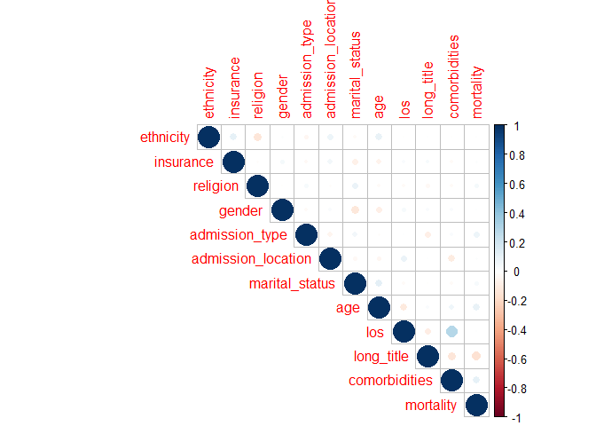

```r
data_cor<-data4[,-8]
data_cor %>% data.matrix() %>% data.frame() %>%
  cor() %>% corrplot::corrplot(type='upper')
```

The correlation plot displays that factors affecting mortality are admission type, age, long_title (disease name), and comorbidities. This plot displays that within the data set, mortaltiy is not affected by ethnicity, insurance, religion, gender, admission_location, marital_status or length of stay.

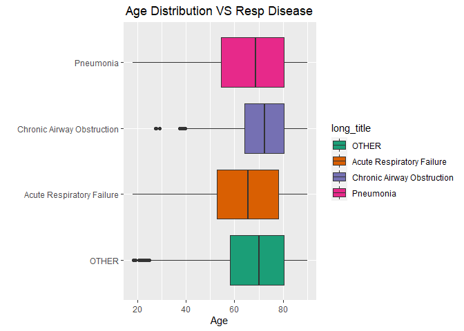

```r
#visualizations

main_religion = data4 %>% dplyr::count(religion, sort=TRUE)%>% filter(n>100) %>% data.frame()%>% droplevels()


#Plot of Age Distribution VS Resp Disease boxplot
ggplot(data=data4)+ geom_boxplot(aes(x=long_title, y= age, fill = long_title))+
 labs(title="Age Distribution VS Resp Disease", x="", y="Age") +
   theme(plot.title = element_text(hjust = 0.5))+
  coord_flip() +
    scale_fill_brewer(palette="Dark2")
```

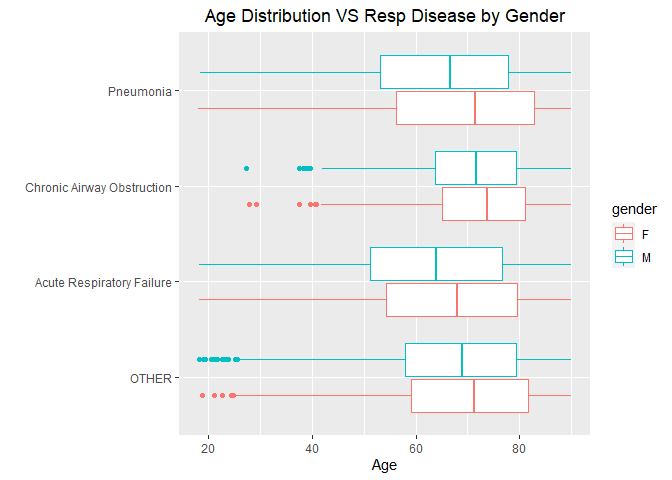

```r
#Plot of Age Distribution VS Resp Disease by Gender
ggplot(data=data4)+ geom_boxplot(aes(x=long_title, y= age,color=gender))+
 labs(title="Age Distribution VS Resp Disease by Gender", x="", y="Age") +
   theme(plot.title = element_text(hjust = 0.5))+
  coord_flip()
```

###SUMMARY OF PLOTS:

Plot of Age Distribution VS Resp Disease boxplot:  
Pneumonia: Most people with pneumonia in data set between the ages of 55-80. The median age about 68 years old. Chronic Airway Obstructions: Most people with Chronic Airway Obstruction in data set between the ages of 65-80. The median age about73 years old. Acute Respiratory Failure: Most people with Acute respirtory illness in data set between the ages of 53-78. The median age about 65 years old. Other:Most people with Other respiratory illnesses in data set between the ages of 58-80. The median age about 70 years old. Most people in this data set with respiratory illnesses are older 50 years old. The ages 60-80 has high population of respirtory illness.The chronic airway obstruction group also has people 25-40 years old. This could suggest the younger people coming in could has been born with respirtory illnesses.

Plot of Age Distribution VS Resp Disease by Gender: Men are entering the hospital younger than women in all 4 repiratory illness categories. The median age for women is slightly higher in each category -even in the “OTHER” category My prediction from this:the people in our data, are at high risk for covid necause they are already susceptible to respiratory illness due to their age